# Data Visualization on Car Dataset

```python
# Importing libraries
import numpy as np
import pandas as pd
import seaborn as sns
import matplotlib.pyplot as plt

%matplotlib inline
```

## Viewing the Data

```python
# Importing data
data = pd.read_csv('car_clean.csv')
data.head()
```

|  | Unnamed: 0 | Location | Year | Kilometers_Driven | Fuel_Type | Transmission | Owner_Type | Seats | Price | Brand | Model | Submodel | Mileage_Value | Engine_CC | Power_bhp |
| --- | --- | --- | --- | --- | --- | --- | --- | --- | --- | --- | --- | --- | --- | --- | --- |
| 0 | 0 | Mumbai | 2010 | 72000 | CNG | Manual | First | 5.0 | 1.75 | Maruti | Wagon | R LXI CNG | 26.60 | 998.0 | 58.16 |
| 1 | 1 | Pune | 2015 | 41000 | Diesel | Manual | First | 5.0 | 12.50 | Hyundai | Creta | 1.6 CRDi SX Option | 19.67 | 1582.0 | 126.20 |
| 2 | 2 | Chennai | 2011 | 46000 | Petrol | Manual | First | 5.0 | 4.50 | Honda | Jazz | V | 18.20 | 1199.0 | 88.70 |
| 3 | 3 | Chennai | 2012 | 87000 | Diesel | Manual | First | 7.0 | 6.00 | Maruti | Ertiga | VDI | 20.77 | 1248.0 | 88.76 |
| 4 | 4 | Coimbatore | 2013 | 40670 | Diesel | Automatic | Second | 5.0 | 17.74 | Audi | A4 | New 2.0 TDI Multitronic | 15.20 | 1968.0 | 140.80 |

```python
data.drop('Unnamed: 0', axis=1, inplace=True)
```

```python
# My colors to be used in exploration
green1 = [22/256, 111/256, 76/256]
blue1 = [29/256, 82/256, 120/256]
green2 = [0/256, 83/256, 47/256]
blue2 = [38/256, 51/256, 86/256]
green3 = [50/256, 199/256, 127/256]
blue3 = [26/256, 196/256, 219/256]
red1 = [125/256, 25/256, 0/256]
red2 = [178/256, 24/256, 71/256]
```

## About Features:

- **Location**: Categorcial Nominal
- **Year**: Numerical Continous
- **Kilometers_Driven**: Numerical
- **Fuel_Type**: Categorical Nominal
- **Transmission**: Categorical Nominal
- **Owner_Type**: Categorical Ordinal
- **Seats**: Numerical Discrete
- **Price**: Numerical Continous
- **Brand, Model & Submodel**: Categorcial Nominal
- **Mileage_Value**: Numerical Continous
- **Engine_CC**: Numerical Continous
- **Power_bhp**: Numerical Continous

# Univariate Explorations

Univariate Explorations are roughly divided into two types of plots:

- Histograms: for Numerical continous
- Bar graph: For all others

### Location Feature

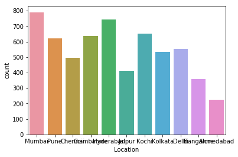

```python
# A categorical feature
sns.countplot(data=data, x='Location')
```

**Problems**:

- THERE IS NO NEED FOR SEPERATE COLOR. Our xlabels IS ALREADY THERE to differentiate between different cities. The usage of colors here is redundant. As a starting point, try to imagine how far can you plot the graph in just plain black and white? Introduce color only when the positional axes and available plot needs additional information to capture.
- The xlabels are haphazard
- The order: If you have a nominal feature (no order), prefer to arrange the bars in order of their occurence

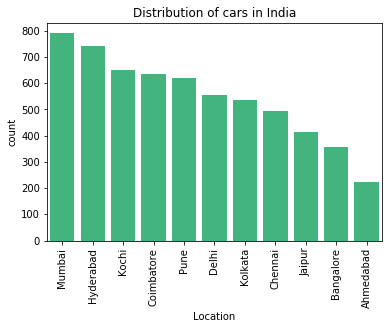

```python
sns.countplot(data=data, x='Location', color=green3, order=data.Location.value_counts().sort_values(ascending=False).index)
plt.title('Distribution of cars in India')
plt.xticks(rotation=90);
```

**Top cities of old cars: Mumbai, Hyderabad, Kochi, Coimbatore. least Ahmedabad**

### Years Feature

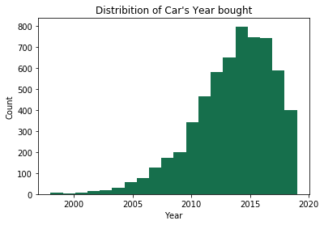

```python
# Numerical Feature
plt.hist(data.Year, bins=20, color=green1);
plt.title('Distribition of Car\'s Year bought')
plt.xlabel('Year')
plt.ylabel('Count');
```

### Kilometers Driven

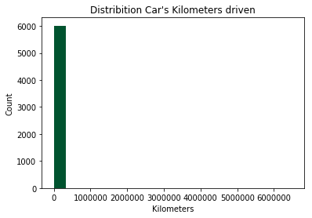

```python
# Numerical Feature
plt.hist(data.Kilometers_Driven, bins=20, color=green2);
plt.title('Distribition Car\'s Kilometers driven')
plt.xlabel('Kilometers')
plt.ylabel('Count');
```

**Ahhh!! We have an outlier**

```
(-3, 300000)
```

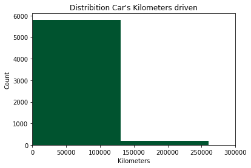

```python
plt.hist(data.Kilometers_Driven, bins=50, color=green2);
plt.title('Distribition Car\'s Kilometers driven')
plt.xlabel('Kilometers')
plt.ylabel('Count');
plt.xlim(-3, 300000)
```

### Fuel Type Feature

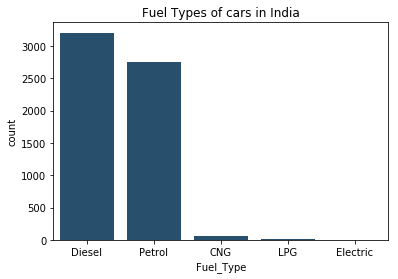

```python
# Categorcial Feature
sns.countplot(data=data, x='Fuel_Type', color=blue1, order=data.Fuel_Type.value_counts().sort_values(ascending=False).index)
plt.title('Fuel Types of cars in India');
```

**Most cars are Diesel & Petrol in India**

### Transmission Feature

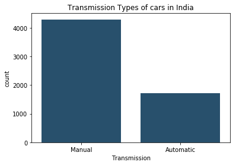

```python
# Categorcial Feature
sns.countplot(data=data, x='Transmission', color=blue1, order=data.Transmission.value_counts().sort_values(ascending=False).index)
plt.title('Transmission Types of cars in India');
```

**Most cars in India are Manual**

### Owner Type

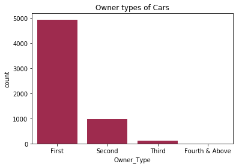

```python
# Categorcial Feature
sns.countplot(data=data, x='Owner_Type', color=red2, order=data.Owner_Type.value_counts().sort_values(ascending=False).index)
plt.title('Owner types of Cars');
```

**NOTE: We have sorted the data based on Number of Observations here. It is WRONG for this case. In case of ORDINAL variables, even though they are categorical, and we see a pattern by descending order of observations, it is a better practice to plot them on the basis of their ordinality. Hence a better plot would be:**

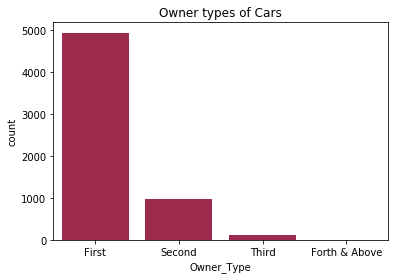

```python
# Categorcial Feature
sns.countplot(data=data, x='Owner_Type', color=red2, order=['First', 'Second', 'Third', 'Forth & Above'])
plt.title('Owner types of Cars');
```

**Note: Though we observe same plots in both cases, it might not be true always***

### Seats Feature

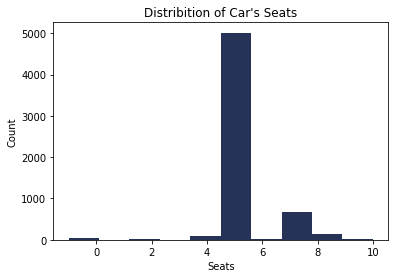

```python
# Numerical Feature
plt.hist(data.Seats, bins=10, color=blue2);
plt.title('Distribition of Car\'s Seats')
plt.xlabel('Seats')
plt.ylabel('Count');
```

**Note**:

- The above plot although looks good isn't a good representation
- We are trying to plot a numerical feature. However, it is a DISCRETE feature.
- Look below how can we improve this

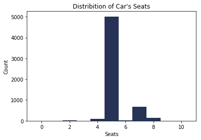

```python
# Numerical Feature
plt.hist(data.Seats, color=blue2, bins=np.arange(-0.5, 11.5, 1));
plt.title('Distribition of Car\'s Seats')
plt.xlabel('Seats')
plt.ylabel('Count');
```

### Price feature

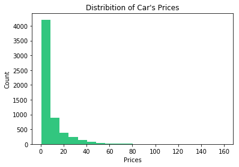

```python
# Numerical Feature
plt.hist(data.Price, bins=20, color=green3);
plt.title('Distribition of Car\'s Prices')
plt.xlabel('Prices')
plt.ylabel('Count');
```

**We have an outlier**

```
(-1, 80)
```

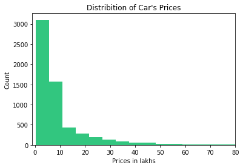

```python
# Numerical Feature
plt.hist(data.Price, bins=30, color=green3);
plt.title('Distribition of Car\'s Prices')
plt.xlabel('Prices in lakhs')
plt.ylabel('Count');
plt.xlim(-1, 80)
```

**Highly right skew**

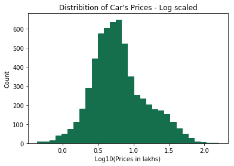

```python
# Numerical Feature
plt.hist(np.log10(data.Price.values), bins=30, color=green1);
plt.title('Distribition of Car\'s Prices - Log scaled')
plt.xlabel('Log10(Prices in lakhs)')
plt.ylabel('Count');
```

**Log of prices is normal distributed**

### Brand Feature

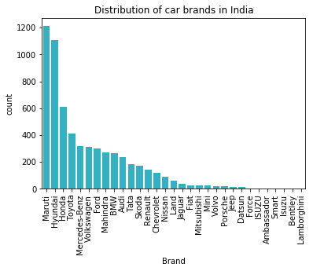

```python
sns.countplot(data=data, x='Brand', color=blue3, order=data.Brand.value_counts().sort_values(ascending=False).index)
plt.title('Distribution of car brands in India')
plt.xticks(rotation=90);
```

**Top 4 cars: Maruti, Hyunday, Honda, toyota**

### Mileage

We will plot this in bivariate because a mileage is best viewed with respect to its fuel type - Petrol, Diesel, CNG, LPG or Electric

### Power Feature

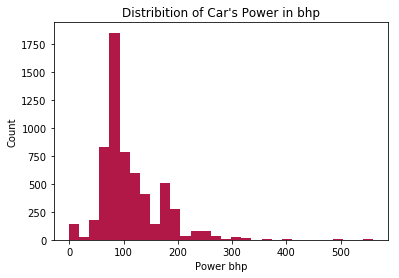

```python
# Numerical Feature
plt.hist(data.Power_bhp, bins=30, color=red2);
plt.title('Distribition of Car\'s Power in bhp')
plt.xlabel('Power bhp')
plt.ylabel('Count');
```

```python
data.Power_bhp.value_counts()
```

```
 74.00     235
-1.00      143
 98.60     131
 73.90     125
 140.00    123
 88.50     112
 78.90     111
 67.04     107
 67.10     107
 82.00     101
 117.30     93
 118.00     90
 121.30     88
 85.80      82
 190.00     79
 126.20     78
 170.00     77
 88.70      75
 70.00      75
 80.00      74
 86.80      74
 174.33     71
 81.86      71
 103.60     69
 81.83      68
 68.00      62
 68.05      61
 184.00     58
 120.00     57
 88.80      57
          ...
 116.40      1
 68.10       1
 231.10      1
 116.90      1
 382.00      1
 110.50      1
 367.00      1
 112.40      1
 199.30      1
 178.40      1
 95.00       1
 236.00      1
 61.00       1
 552.00      1
 560.00      1
 237.40      1
 35.50       1
 321.00      1
 120.33      1
 488.10      1
 71.01       1
 246.74      1
 550.00      1
 362.90      1
 261.50      1
 254.00      1
 103.00      1
 301.73      1
 261.00      1
 114.40      1
Name: Power_bhp, Length: 370, dtype: int64
```

### Engine CC Feature

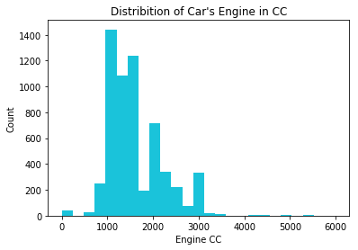

```python
# Numerical Feature
plt.hist(data.Engine_CC, bins=25, color=blue3);
plt.title('Distribition of Car\'s Engine in CC')
plt.xlabel('Engine CC')
plt.ylabel('Count');
```

# Bivariate Explorations

### Mileage & Fuel_Type

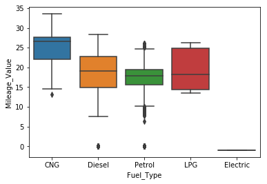

```python
# Categorical and Mileage
# Option 1: Box Plot
sns.boxplot(data=data, x='Fuel_Type', y='Mileage_Value')
```

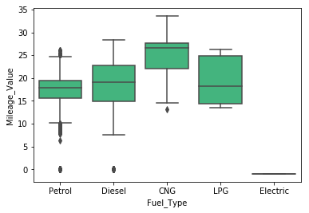

```python
# Improved plot
sns.boxplot(data=data, x='Fuel_Type', y='Mileage_Value', color=green3,
           order = ['Petrol', 'Diesel', 'CNG', 'LPG', 'Electric'])
```

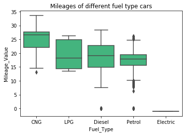

```python
# Another Improved plot
sns.boxplot(data=data, x='Fuel_Type', y='Mileage_Value', color=green3,
           order = data.groupby('Fuel_Type')['Mileage_Value'].mean().sort_values(ascending=False).index)
plt.title('Mileages of different fuel type cars');
```

**Order of Mileage: CNG > LPG, Diesel > Petrol**

- Mileage of ELectric Vehicles are NaN
- LPG has high variability
- CNG is highly left skew

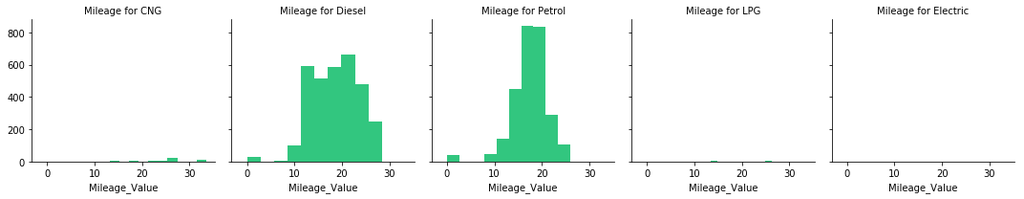

```python
# option 2: FacetGrid
g = sns.FacetGrid(data=data, col="Fuel_Type")
g.map(plt.hist, 'Mileage_Value', color=green3)
g.set_titles('Mileage for {col_name}');
```

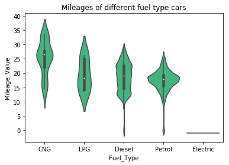

```python
# option 3: Violin Plot
sns.violinplot(data=data, x='Fuel_Type', y='Mileage_Value', color=green3,
           order = data.groupby('Fuel_Type')['Mileage_Value'].mean().sort_values(ascending=False).index)
plt.title('Mileages of different fuel type cars');
```

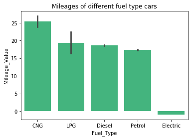

```python
# option 4: Barplot
# Note: A barplot has a categoricala var on x axis and the suary statistic (mean and std) on y axis
sns.barplot(data=data, x='Fuel_Type', y='Mileage_Value', color=green3,
           order = data.groupby('Fuel_Type')['Mileage_Value'].mean().sort_values(ascending=False).index)
plt.title('Mileages of different fuel type cars');
```

### Location and Price

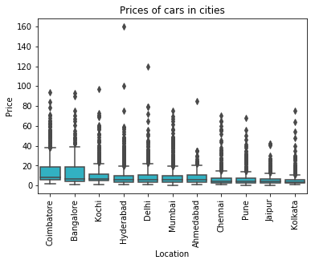

```python
# Categorical & Numerical
# We can choose any of the 4 options from above
# Let's choose boxplot
sns.boxplot(data=data, x='Location', y='Price', color=blue3,
           order = data.groupby('Location')['Price'].mean().sort_values(ascending=False).index)
plt.title('Prices of cars in cities');
plt.xticks(rotation=90);
```

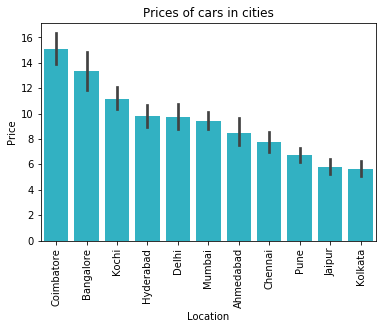

```python
# A better plot
sns.barplot(data=data, x='Location', y='Price', color=blue3,
           order = data.groupby('Location')['Price'].mean().sort_values(ascending=False).index)
plt.title('Prices of cars in cities');
plt.xticks(rotation=90);
```

**Highest average price of car in Coimbatore and lowest in Kolkata**

### Year and price

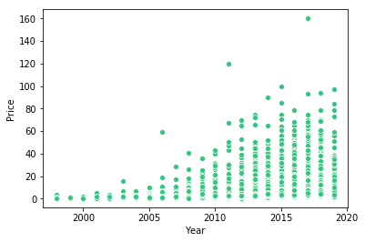

```python
# numerical vs numerical: Scatterplot
sns.scatterplot(data=data, x='Year', y='Price', color=green3)
```

**Oops!! This plot doesn't look good! Why? because Year is a discrete variable. This thing is known as 'overplotting'**

**See more here:** https://julienbeaulieu.gitbook.io/wiki/sciences/programming/data-analysis/data-visualization/bivariate-exploration-of-data/overplotting-transparency-and-jitter

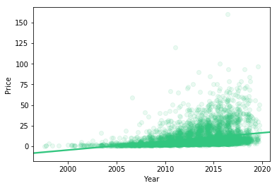

```python
sns.regplot(data = data, x = 'Year', y = 'Price', fit_reg = True,
           x_jitter = 0.7, scatter_kws = {'alpha' : 1/10}, color=green3);
```

**Did not help much**

```
Text(0.5,1,'Price vs Year')
```

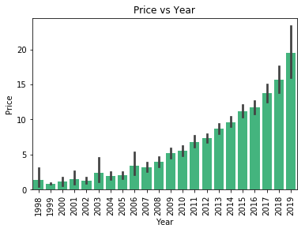

```python
sns.barplot(data=data, x='Year', y='Price', color=green3)
plt.xticks(rotation=90);
plt.title('Price vs Year')
```

**Price has a direct correlation with Price**

### Kilometers Driven and Price

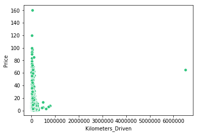

```python
# numerical vs numerical: Scatterplot
sns.scatterplot(data=data, x='Kilometers_Driven', y='Price', color=green3)
```

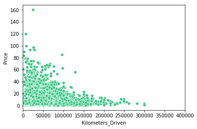

```python
sns.scatterplot(data=data, x='Kilometers_Driven', y='Price', color=green3)
plt.xlim(-3, 400000);
```

**No major correlation**

### Fuel Type And Price

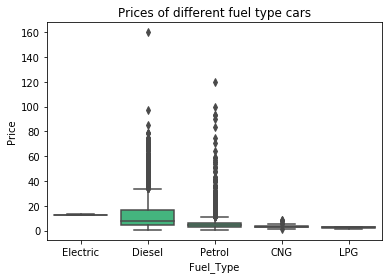

```python
## Categorical vs Numerical
# Let us use boxplot
sns.boxplot(data=data, x='Fuel_Type', y='Price', color=green3,
           order = data.groupby('Fuel_Type')['Price'].mean().sort_values(ascending=False).index)
plt.title('Prices of different fuel type cars');
```

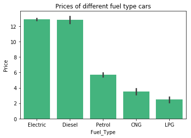

```python
#Barplot
sns.barplot(data=data, x='Fuel_Type', y='Price', color=green3,
           order = data.groupby('Fuel_Type')['Price'].mean().sort_values(ascending=False).index)
plt.title('Prices of different fuel type cars');
```

**Electric and Diesel cars are expensive, while CNG and LPG are cheaper**